# Theory-driven analysis for ecological data: Confronting population models with time series data

Author

Benjamin Rosenbaum

Published

March 17, 2026

We start by loading the packages `rstan` for fitting and `coda` for plotting Bayesian model output. A random seed is set for reproducability of the stochastic simulations.

```r
rm(list=ls())
library("rstan")
library("coda")
set.seed(100) # random seed
```

# Modeling

We simulate a time series with known parametrization ($r,\alpha$). The Ricker model for a single population
$$Z_{i+1}=Z_i \cdot e^{r(1-\alpha Z_i)}$$
is coded featuring environmental and demographic stochasticity (process noise)
$$Z_{i+1}\sim \text{Poisson} \left( Z_i \cdot e^{r(1-\alpha Z_i)+{\epsilon_i}} \right), \epsilon_i\sim\text{Normal}(0,\sigma).$$
We simulate a measurement process, where only a fraction $p\in[0,1]$ of the total volume or area is observed, where individuals are counted. This is realised by a Binomial distribution, and upscaling the estimate to the total volume again.
$$Y_i\sim\frac{1}{p}\cdot\text{Binomial}(Z_i,p).$$
The resulting time series $Y_1,\dots,Y_T$ then features variance that scales with $Z^2$ (environmental noise $\epsilon$) and with $Z$ (demographic noise and observation error).

```r
TT = 14 # total time: 14 days
Z = numeric(TT) # process time series

s_proc = 0.05 # process error standard deviation for environmental noise

r = 0.8 # growth rate
K = 1000 # carrying capacity
alpha = 1/K # competition

# process equation: Ricker model
Z[1]=100
for(i in 1:(TT-1)){
  Z[i+1] = Z[i]*exp(r*(1-alpha*Z[i]))      # deterministic prediction
  Z[i+1] = Z[i+1]*exp(rnorm(1, 0, s_proc)) # environmental noise
  Z[i+1] = rpois(1, Z[i+1])                # demographic noise
}

# observation: count abundances in fraction p of total volume
p = 0.1
Y = rbinom(TT,Z,rep(p,TT))/p
```

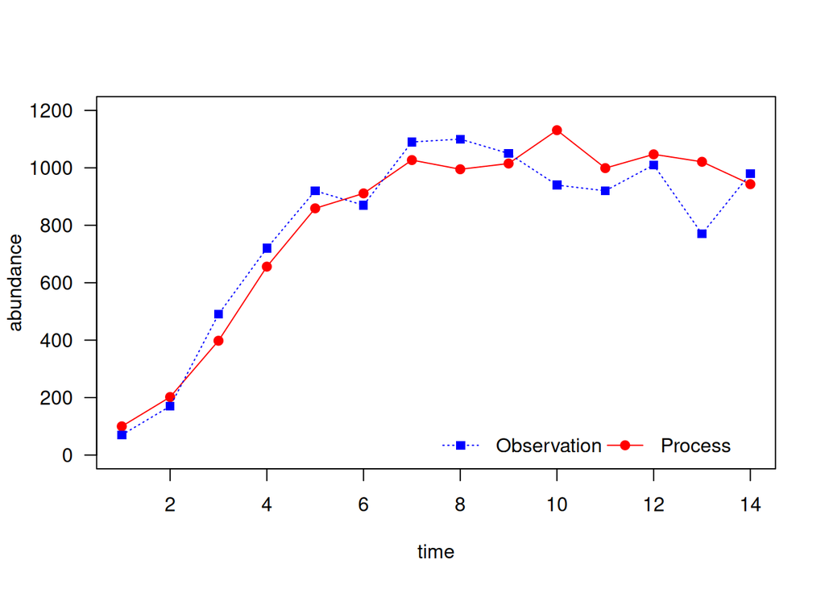

```r
plot(1:TT, Z,
     pch = 19, col="red", ty = "o",
     xlab = "time", ylab = "abundance",
     ylim=c(0,1.2*K), las=1)
points(1:TT, Y,
       pch=15, col="blue", ty="o", lty = 3)
legend("bottomright",
       legend = c("Observation", "Process"),
       pch = c(15, 19),
       col = c("blue", "red"),
       lty = c(3, 1),
       horiz=TRUE, bty="n")
```

# Fitting obs error only

## Model

The model is written in a separate file `"model_obs.stan"`. As usual, the blocks `data`, `parameters` and `model` are used. When using the initial abundance as an additional parameter `U1`, the complete trajectory `U[i]` can be computed for given model parameters `r` and `alpha`. We assume a lognormal distribution of the observations `Y` around predictions `U` with a standard deviation parameter `s_obs`.

```r
writeLines(readLines("model_obs.stan"))
```

```
data {
  int TT;
  vector[TT] Y;
}

parameters {
  real<lower=0> r;
  real<lower=0> alpha;
  real<lower=0> s_obs;
  real<lower=0> U1;
}

model {
  vector[TT] U; // prediction variable

  // weak priors
  r ~ exponential(1);
  alpha ~ exponential(1);
  s_obs ~ normal(0, 1);
  U1 ~ normal(100, 10);

  // predictions
  U[1] = U1;
  for(t in 2:TT){
    U[t] = U[t-1]*exp(r*(1-alpha*U[t-1]));
  }

  // observation error
  for(t in 1:TT){
    Y[t] ~ lognormal(log(U[t]), s_obs);
  }
}
```

## Fitting

For Stan, the data has to be coded as a list. Initial parameter guesses for MCMC sampling can be provided.

```r
data = list(Y=Y, TT=TT)

inits = list(r=0.5,
             alpha=1e-3,
             s_obs=0.1,
             U1=data$Y[1])
```

```r
fit_obs = stan(file = "model_obs.stan",
               data = data,
               chains = 3,
               cores = 3,
               init = rep(list(inits),3),
               iter = 4000)
```

Model output looks good.

```r
print(fit_obs)
```

```
Inference for Stan model: anon_model.
3 chains, each with iter=4000; warmup=2000; thin=1;
post-warmup draws per chain=2000, total post-warmup draws=6000.

       mean se_mean   sd  2.5%   25%   50%   75%  97.5% n_eff Rhat
r      0.96    0.00 0.08  0.79  0.91  0.97  1.02   1.13  3084    1
alpha  0.00    0.00 0.00  0.00  0.00  0.00  0.00   0.00  3308    1
s_obs  0.14    0.00 0.04  0.09  0.12  0.14  0.16   0.25  2650    1
U1    84.72    0.17 8.51 69.96 78.63 83.91 90.19 103.54  2491    1
lp__   1.24    0.04 1.68 -2.98  0.46  1.63  2.47   3.32  1962    1

Samples were drawn using NUTS(diag_e) at Thu Mar 12 11:29:28 2026.
For each parameter, n_eff is a crude measure of effective sample size,
and Rhat is the potential scale reduction factor on split chains (at
convergence, Rhat=1).
```

Posterior samples are transformed for plotting the model output from the `coda` package.

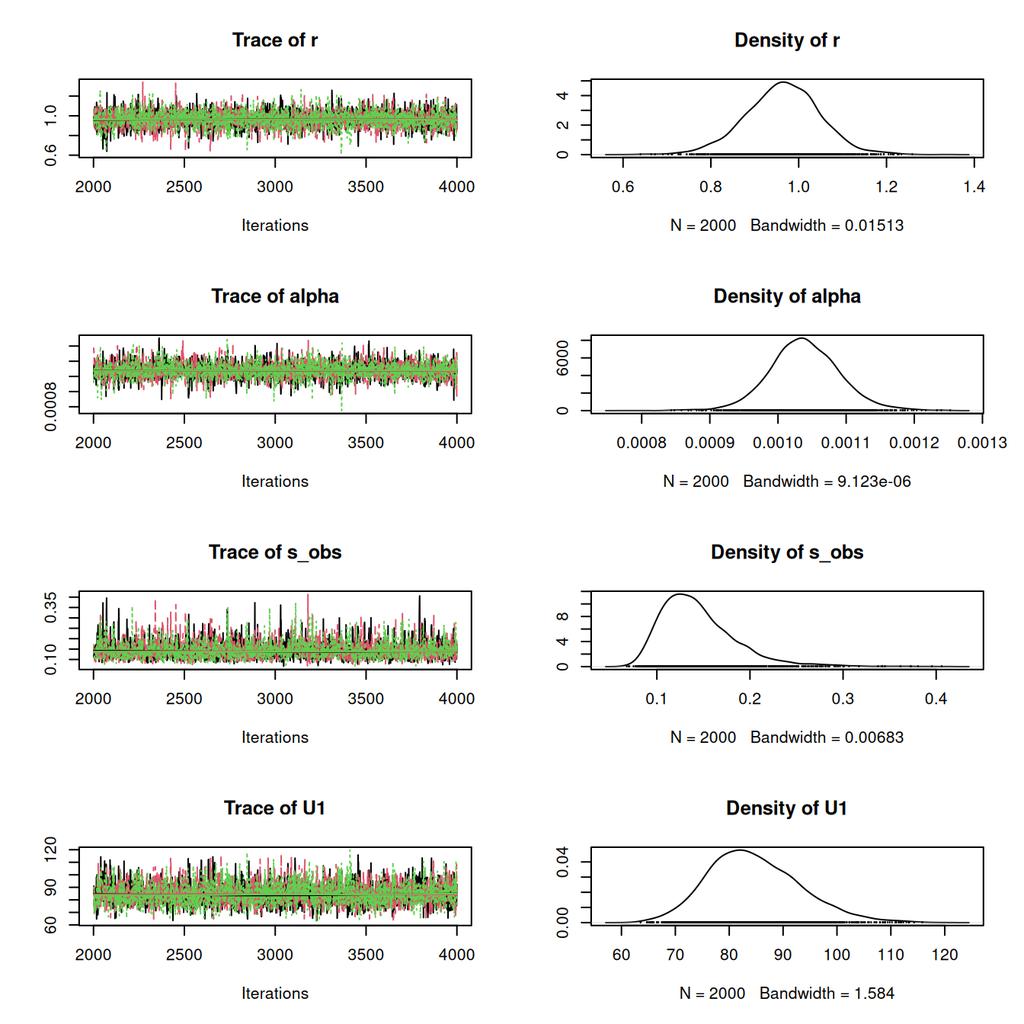

```r
samples = As.mcmc.list(fit_obs)
plot(samples[, 1:4])
```

The competition coefficient `alpha=0.001` is estimated fairly accurate, but the growth rate `r=0.8` is overestimated in presence of process and observation error in the data.

## Predictions

Model predictions can be computed from the samples of the posterior. Each sample generates a predicted trajectory. When we compute multiple trajectories (1 from each of the 1000s of samples), the mean trajectory and 95% credible intervals can be extracted.

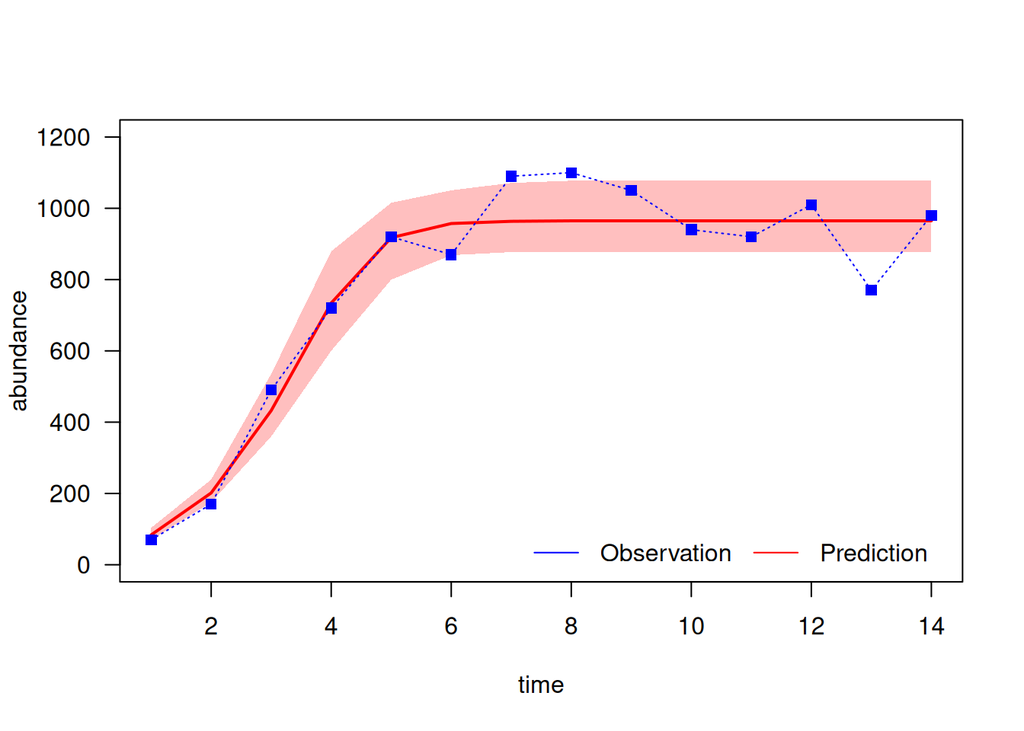

```r
samples = as.matrix(fit_obs) # extract samples as matrix
# object for predictions: 1 row per sample, 1 column per observation
U.pred = matrix(NA, nrow=1000, ncol=TT)

for(j in 1:1000){ # loop over samples
  # extract parameters from posterior
  U.pred[j,1] = samples[j,"U1"]
  r.pred = samples[j,"r"]
  a.pred = samples[j,"alpha"]
  for(i in 1:(TT-1)){ # loop through time
    # compute prediction
    U.pred[j,i+1] = U.pred[j,i]*exp(r.pred*(1-a.pred*U.pred[j,i]))
  }
}

# extact quantiles
U.pred.q = apply(U.pred, 2, function(x) quantile(x, probs=c(0.025, 0.50, 0.975)))

plot(1:TT, Y, type="n",
     xlab = "time", ylab = "abundance",
     ylim=c(0,1.2*K), las=1)

# 95% quantiles:
polygon(c(1:TT,TT:1),c(U.pred.q[1,],rev(U.pred.q[3,])),
        col=adjustcolor("red", alpha.f=0.25) , border=NA)
# median regression line
lines(1:TT, U.pred.q[2,], col="red", lwd=2)
# data
points(1:TT, Y, pch=15, col="blue", ty="o", lty = 3)

legend("bottomright",
       legend = c("Observation", "Prediction"),
       col = c("blue", "red"),
       lty = c(1, 1),
       horiz=TRUE, bty="n")
```

# Fitting proc error only

## Model

Here, we predict `U[i]` one-step-ahead, directly from the previous observation `Y[i-1]`, given the model parameters `r` and `alpha`. We assume a lognormal distribution of the obseravtions `Y` around these piecewise predictions `U` with a standard deviation parameter `s_proc`.

```r
writeLines(readLines("model_proc.stan"))
```

```
data {
  int TT;
  vector[TT] Y;
}

parameters {
  real<lower=0> r;
  real<lower=0> alpha;
  real<lower=0> s_proc;
}

model {
  vector[TT] U; // prediction variable

  // weak priors
  r ~ exponential(1);
  alpha ~ exponential(1);
  s_proc ~ normal(0, 1);

  // predictions
  for(t in 2:TT){
    U[t] = Y[t-1]*exp(r*(1-alpha*Y[t-1]));
  }

  // process error
  for(t in 2:TT){
    Y[t] ~ lognormal(log(U[t]), s_proc);
  }
}
```

## Fitting

For Stan, the data has to be coded as a list. Initial parameter guesses for MCMC sampling can be provided.

```r
data = list(Y=Y, TT=TT)

inits = list(r=0.5,
             alpha=1e-3,
             s_proc=0.1)
```

```r
fit_proc = stan(file = "model_proc.stan",
                data = data,
                chains = 3,
                cores = 3,
                init = rep(list(inits),3),
                iter = 4000)
```

Model output looks good.

```r
print(fit_proc)
```

```
Inference for Stan model: anon_model.
3 chains, each with iter=4000; warmup=2000; thin=1;
post-warmup draws per chain=2000, total post-warmup draws=6000.

        mean se_mean   sd  2.5%   25%   50%   75% 97.5% n_eff Rhat
r       1.02    0.00 0.11  0.79  0.96  1.03  1.09  1.23  3036    1
alpha   0.00    0.00 0.00  0.00  0.00  0.00  0.00  0.00  3579    1
s_proc  0.14    0.00 0.04  0.09  0.12  0.14  0.16  0.23  2751    1
lp__   -2.20    0.04 1.47 -6.10 -2.84 -1.81 -1.13 -0.57  1753    1

Samples were drawn using NUTS(diag_e) at Thu Mar 12 11:32:37 2026.
For each parameter, n_eff is a crude measure of effective sample size,
and Rhat is the potential scale reduction factor on split chains (at
convergence, Rhat=1).
```

Posterior samples are transformed for plotting the model output from the `coda` package.

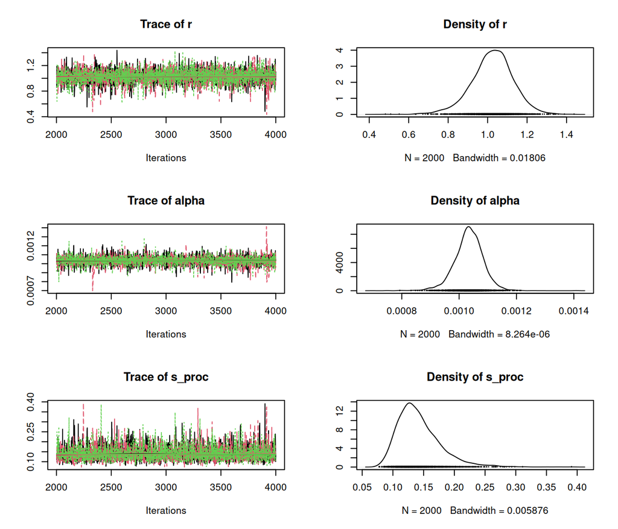

```r
samples = As.mcmc.list(fit_proc)
plot(samples[, 1:3])
```

Again, growth rate `r=0.8` is overestimated in presence of process and observation error in the data.

## Predictions

For this one-step ahead fitting, it’s suitable to plot predicted values for $Y_{t+1}$ against $Y_t$.

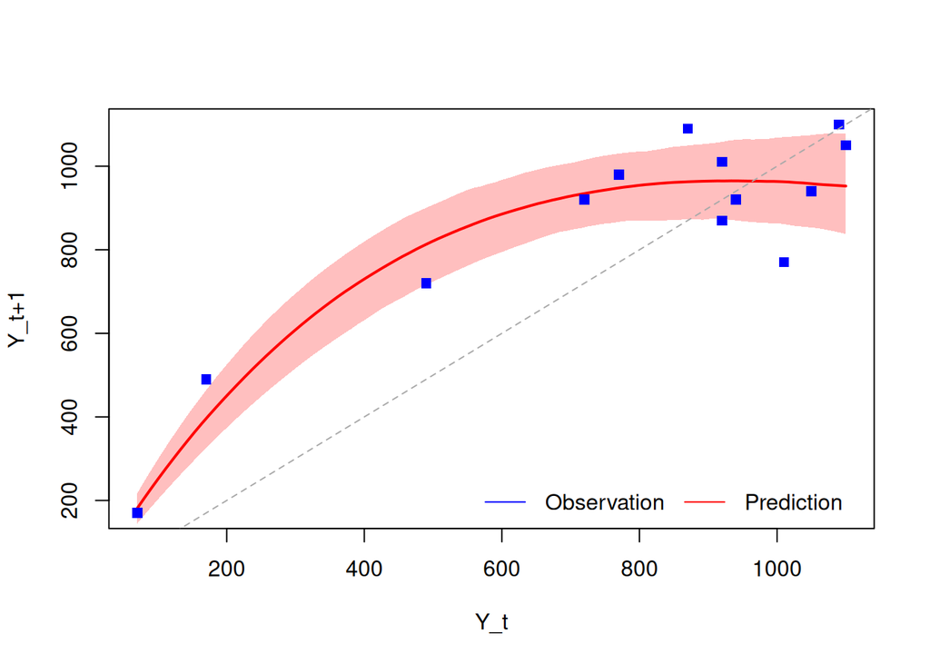

```r
samples = as.matrix(fit_proc) # extract samples as matrix

# reshape data into Y_t and Y_t+1 of same length
Y.this = Y[1:(TT-1)]
Y.next = Y[2:TT]

# objects for predictions: 1 row per sample
U.this = seq(min(Y.this), max(Y.this), length.out=100)
U.next = matrix(NA, nrow=1000, ncol=100)

for(j in 1:1000){ # loop over samples
  # extract parameters from posterior
  r.pred = samples[j,"r"]
  a.pred = samples[j,"alpha"]
  # compute all one-step ahead predictions
  U.next[j, ] = U.this*exp(r.pred*(1-a.pred*U.this))
}

# extract quantiles
U.next.q = apply(U.next, 2, function(x) quantile(x, probs=c(0.025, 0.50, 0.975)))

plot(Y.this, Y.next, type="n", xlab="Y_t", ylab="Y_t+1")

# 95% quantiles:
polygon(c(U.this,rev(U.this)), c(U.next.q[1,],rev(U.next.q[3,])),
        col=adjustcolor("red", alpha.f=0.25) , border=NA)
# median regression line:
lines(U.this, U.next.q[2,], col="red", lwd=2)
# data:
points(Y.this, Y.next, pch = 15, col="blue")

legend("bottomright",
       legend = c("Observation", "Prediction"),
       col = c("blue", "red"),
       lty = c(1, 1),
       horiz=TRUE, bty="n")

abline(0,1, col="darkgray", lty=2)
```

The 1-1-line separates predicted population growth from decline.

## Alternative predictions

The Ricker model (and also the Gompertz model) can be written as a linear model, that could also be fitted with `lm()`.

$$\log\left(\frac{Y_{t+1}}{Y_{t}}\right) \sim r\left(1-\alpha Y_{t}\right)$$

Here, we plot observed log growth versus predicted log growth, to see that this is just a linear regression. Other models such as the theta-logistic model, however, cannot be linearized.

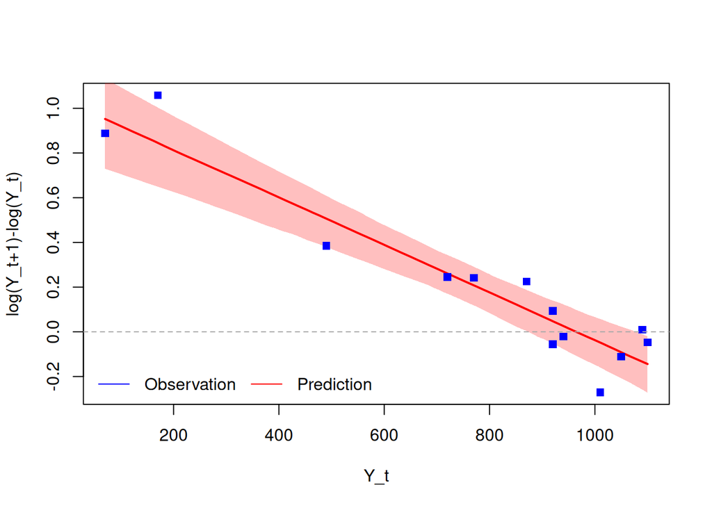

```r
samples = as.matrix(fit_proc) # extract samples as matrix

# reshape data into Y_t and Y_t+1 of same length
Y.this = Y[1:(TT-1)]
Y.next = Y[2:TT]

# objects for predictions: 1 row per sample
U.this = seq(min(Y), max(Y), length.out=100)
U.grow = matrix(NA, nrow=1000, ncol=100)

for(j in 1:1000){ # loop over samples
  # extract parameters from posterior
  r.pred = samples[j,"r"]
  a.pred = samples[j,"alpha"]
  # compute all one-step ahead predictions
  U.grow[j, ] = r.pred*(1-a.pred*U.this)
}

# extract quantiles
U.grow.q = apply(U.grow, 2, function(x) quantile(x, probs=c(0.025, 0.50, 0.975)))

plot(Y.this, log(Y.next/Y.this), type="n", xlab="Y_t", ylab="log(Y_t+1)-log(Y_t)")

# 95% quantiles:
polygon(c(U.this,rev(U.this)), c(U.grow.q[1,],rev(U.grow.q[3,])),
        col=adjustcolor("red", alpha.f=0.25) , border=NA)
# median regression line:
lines(U.this, U.grow.q[2,], col="red", lwd=2)
# data:
points(Y.this, log(Y.next/Y.this), pch = 15, col="blue")

legend("bottomleft",
       legend = c("Observation", "Prediction"),
       col = c("blue", "red"),
       lty = c(1, 1),
       horiz=TRUE, bty="n")

abline(0,0, col="darkgray", lty=2)
```

# Fitting a state-space model

## Model

If we want to to account for both process and observation error, estimated true states `Z[i]` have to be modeled as latent parameters. This time series features process error when compared to the one-step-ahead predictions `U[i]`, for which we choose a lognormal distribution with standard deviation `s_proc`. Also, observed states `Y[i]` are assumed to have observation error with a lognormal distribution with standard deviation `s_obs`.

```r
writeLines(readLines("model_ssm.stan"))
```

```
data {
  int TT;
  vector[TT] Y;
}

parameters {
  real<lower=0> r;
  real<lower=0> alpha;
  real<lower=0> s_proc;
  real<lower=0> s_obs;
  vector[TT] Z;
}

model {
  vector[TT] U; // prediction variable

  // weak priors
  r ~ exponential(1);
  alpha ~ exponential(1);
  s_proc ~ normal(0, 1);
  s_obs ~ normal(0, 1);
  Z[1] ~ normal(100, 10);

  // predictions and process error
  for(t in 2:TT){
    U[t] = Z[t-1]*exp(r*(1-alpha*Z[t-1]));
    Z[t] ~ lognormal(log(U[t]), s_proc);
  }

  // observation error
  for(t in 1:TT){
    Y[t] ~ lognormal(log(Z[t]), s_obs);
  }
}
```

## Fitting

For Stan, the data has to be coded as a list. Initial parameter guesses for MCMC sampling can be provided. Here, we tweak a parameter of the MCMC algorithm to help with convergence. The default value for `adapt_delta` is `0.8` and we increase it to `0.99`.

```r
data = list(Y=Y, TT=TT)

inits = list(r=0.5,
             alpha=1e-3,
             s_proc=0.1,
             s_obs=0.1,
             Z=data$Y)
```

```r
fit_ssm <- stan(file = "model_ssm.stan",
                data = data,
                chains = 3,
                cores = 3,
                init = rep(list(inits),3),
                iter = 4000,
                control = list(adapt_delta=0.99))
```

Model output looks OK.

```r
print(fit_ssm)
```

```
Inference for Stan model: anon_model.
3 chains, each with iter=4000; warmup=2000; thin=1;
post-warmup draws per chain=2000, total post-warmup draws=6000.

          mean se_mean    sd   2.5%    25%    50%     75%   97.5% n_eff Rhat
r         0.96    0.00  0.10   0.76   0.90   0.97    1.03    1.16  2033 1.00
alpha     0.00    0.00  0.00   0.00   0.00   0.00    0.00    0.00  1368 1.00
s_proc    0.08    0.00  0.05   0.01   0.04   0.07    0.10    0.20   265 1.02
s_obs     0.13    0.00  0.05   0.04   0.10   0.13    0.16    0.24   752 1.00
Z[1]     83.28    0.24  8.84  68.78  76.79  82.37   89.18  101.91  1388 1.00
Z[2]    196.19    0.49 18.49 165.56 183.31 194.79  207.23  235.72  1404 1.00
Z[3]    444.31    1.10 46.08 361.04 414.18 442.40  471.21  539.47  1761 1.00
Z[4]    734.07    1.51 69.97 602.85 691.25 731.83  772.94  877.01  2147 1.00
Z[5]    917.97    1.53 73.68 779.27 873.63 916.00  959.35 1064.86  2325 1.00
Z[6]    934.06    1.83 71.90 796.14 888.26 934.55  977.48 1082.33  1551 1.00
Z[7]   1000.68    2.59 82.29 855.37 947.47 992.78 1049.21 1180.26  1010 1.01
Z[8]   1002.11    3.09 83.06 857.68 947.24 995.40 1050.69 1181.35   722 1.01
Z[9]    991.14    1.97 77.97 848.63 940.98 986.32 1037.13 1156.61  1559 1.00
Z[10]   960.08    1.57 73.31 819.96 916.08 956.40 1002.36 1115.52  2191 1.00
Z[11]   954.02    1.74 73.82 815.51 909.20 951.19  993.81 1110.24  1809 1.00
Z[12]   978.89    1.73 78.09 839.22 931.78 974.76 1020.72 1142.49  2031 1.00
Z[13]   908.70    3.32 87.35 743.07 850.16 912.69  966.79 1070.56   690 1.01
Z[14]   969.29    1.51 71.98 833.04 925.73 966.17 1009.65 1120.92  2284 1.00
lp__    -71.79    0.71  9.51 -88.72 -77.72 -72.78  -66.76  -49.31   181 1.02

Samples were drawn using NUTS(diag_e) at Thu Mar 12 12:33:17 2026.
For each parameter, n_eff is a crude measure of effective sample size,
and Rhat is the potential scale reduction factor on split chains (at
convergence, Rhat=1).
```

Posterior samples are transformed for plotting the model output from the `coda` package.

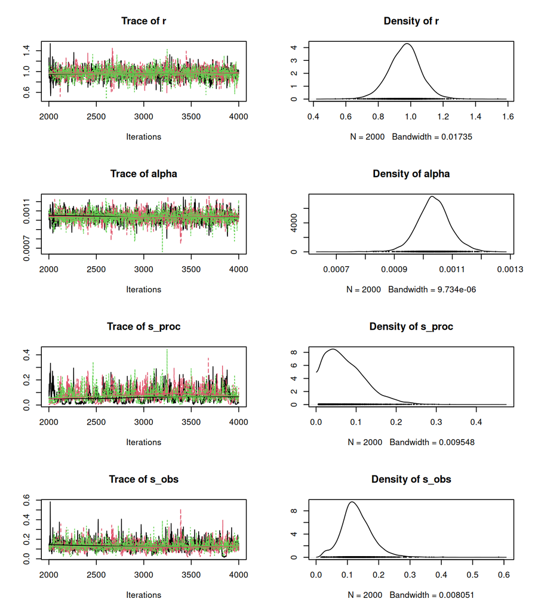

```r
samples = As.mcmc.list(fit_ssm)
plot(samples[, 1:4])
```

Even with the SSM, growth rate `r=0.8` is overestimated. It looks like this single timeseries does not contain enough information to estimate the growth rate accurately. With more replications, a higher temporal sampling frequency, or a higher sampling effort (sampling more than just 10% of the volume), more accurate estimates should be possible.

## Predictions

Estimated true states `Z[i]` and their credible intervals can be directly extracted from the model output.

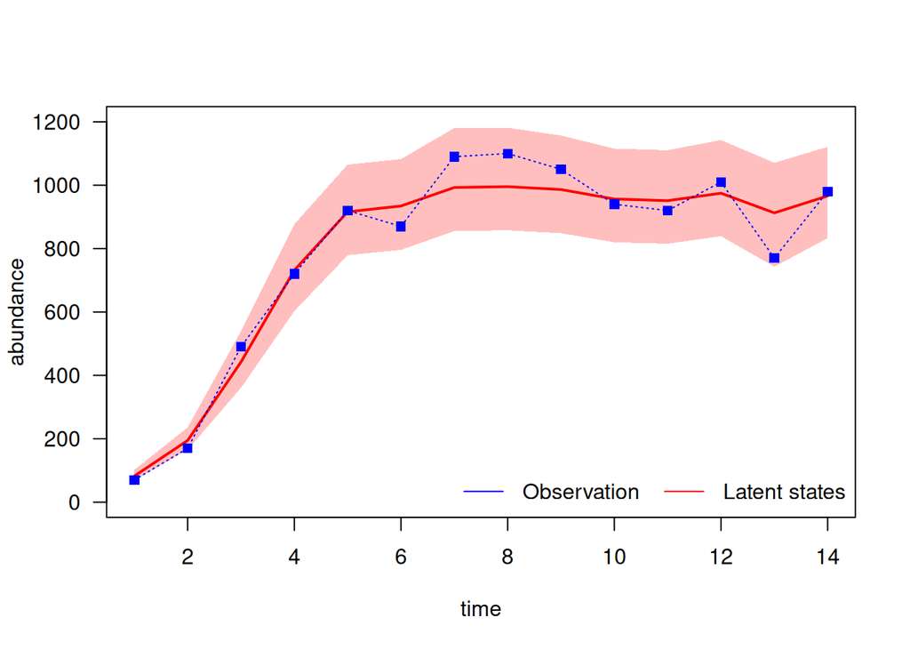

```r
Z_med = summary(fit_ssm)$summary[5:18, "50%"]
Z_lbd = summary(fit_ssm)$summary[5:18, "2.5%"]
Z_ubd = summary(fit_ssm)$summary[5:18, "97.5%"]

plot(1:TT, Z, type="n",
     xlab = "time", ylab = "abundance",
     ylim=c(0,1.2*K), las=1)
polygon(c(1:TT,TT:1),c(Z_lbd,rev(Z_ubd)), col=adjustcolor("red", alpha.f=0.25) , border=NA)
lines(1:TT, Z_med, col="red", lwd=2)
points(1:TT, Y,
       pch=15, col="blue", ty="o", lty = 3)
legend("bottomright",
       legend = c("Observation", "Latent states"),
       col = c("blue", "red"),
       lty = c(1, 1),
       horiz=TRUE, bty="n")
```